# Cope scale scoring

COPE

We are interested in how people respond when they confront difficult or stressful events in their lives. There are lots of ways to try to deal with stress. This questionnaire asks you to indicate what you generally do and feel, when you experience stressful events. Obviously, different events bring out somewhat different responses, but think about what you usually do when you are under a lot of stress.

Then respond to each of the following items by blackening one number on your answer sheet for each, using the response choices listed just below. Please try to respond to each item separately in your mind from each other item. Choose your answers thoughtfully, and make your answers as true FOR YOU as you can. Please answer every item. There are no “right” or “wrong” answers, so choose the most accurate answer for YOU–not what you think “most people” would say or do. Indicate what YOU usually do when YOU experience a stressful event.

```
   1 = I usually don't  do this at all
   2 = I usually do this a little bit
   3 = I usually do this a medium amount
   4 = I usually do this a lot
```

1. I try to grow as a person as a result of the experience.
2. I turn to work or other substitute activities to take my mind off things.
3. I get upset and let my emotions out.
4. I try to get advice from someone about what to do.
5. I concentrate my efforts on doing something about it.
6. I say to myself “this isn’t real.”
7. I put my trust in God.
8. I laugh about the situation.
9. I admit to myself that I can’t deal with it, and quit trying.
10. I restrain myself from doing anything too quickly.
11. I discuss my feelings with someone.
12. I use alcohol or drugs to make myself feel better.
13. I get used to the idea that it happened.
14. I talk to someone to find out more about the situation.
15. I keep myself from getting distracted by other thoughts or activities.
16. I daydream about things other than this.
17. I get upset, and am really aware of it.
18. I seek God’s help.
19. I make a plan of action.
20. I make jokes about it.
21. I accept that this has happened and that it can’t be changed.
22. I hold off doing anything about it until the situation permits.
23. I try to get emotional support from friends or relatives.
24. I just give up trying to reach my goal.
25. I take additional action to try to get rid of the problem.
26. I try to lose myself for a while by drinking alcohol or taking drugs.
27. I refuse to believe that it has happened.
28. I let my feelings out.
29. I try to see it in a different light, to make it seem more positive.
30. I talk to someone who could do something concrete about the problem.
31. I sleep more than usual.
32. I try to come up with a strategy about what to do.
33. I focus on dealing with this problem, and if necessary let other things slide a little.
34. I get sympathy and understanding from someone.
35. I drink alcohol or take drugs, in order to think about it less.
36. I kid around about it.
37. I give up the attempt to get what I want.
38. I look for something good in what is happening.
39. I think about how I might best handle the problem.
40. I pretend that it hasn’t really happened.
41. I make sure not to make matters worse by acting too soon.
42. I try hard to prevent other things from interfering with my efforts at dealing with this.
43. I go to movies or watch TV, to think about it less.
44. I accept the reality of the fact that it happened.
45. I ask people who have had similar experiences what they did.
46. I feel a lot of emotional distress and I find myself expressing those feelings a lot.
47. I take direct action to get around the problem.
48. I try to find comfort in my religion.
49. I force myself to wait for the right time to do something.
50. I make fun of the situation.
51. I reduce the amount of effort I’m putting into solving the problem.
52. I talk to someone about how I feel.
53. I use alcohol or drugs to help me get through it.
54. I learn to live with it.
55. I put aside other activities in order to concentrate on this.
56. I think hard about what steps to take.
57. I act as though it hasn’t even happened.
58. I do what has to be done, one step at a time.
59. I learn something from the experience.
60. I pray more than usual.

Scales (sum items listed, with no reversals of coding):

Positive reinterpretation and growth: 1, 29, 38, 59 Mental disengagement: 2, 16, 31, 43 Focus on and venting of emotions: 3, 17, 28, 46 Use of instrumental social support: 4, 14, 30, 45 Active coping: 5, 25, 47, 58 Denial: 6, 27, 40, 57 Religious coping: 7, 18, 48, 60 Humor: 8, 20, 36, 50 Behavioral disengagement: 9, 24, 37, 51 Restraint: 10, 22, 41, 49 Use of emotional social support: 11, 23, 34, 52 Substance use: 12, 26, 35, 53 Acceptance: 13, 21, 44, 54 Suppression of competing activities: 15, 33, 42, 55 Planning: 19, 32, 39, 56

```r
library("here")
library("tidyverse")
library("MplusAutomation")
library("gt")
library("glue")
library("kableExtra")
library("misty")
library("lavaan")
library("AICcmodavg")
library("nonnest2")
library("DiagrammeR")
library("lavaan")
library("tidyLPA")
library("semTools")
library("brms")
library("MBESS")
library("ufs")
library("robmed")
library("careless")
library("psych")

options("max.print" = .Machine$integer.max)

# Make random things reproducible
set.seed(1234)

options(
  mc.cores = 6 # Use 6 cores
)

source(here::here("src", "R", "functions", "funs_add_neoffi60_subscales.R"))
source(here::here("src", "R", "functions", "funs_correct_iesr_scores.R"))
source(here::here("src", "R", "functions", "funs_plot_job_qualification.R"))
source(here::here("src", "R", "functions", "funs_generate_all_items_df.R"))

scale_this <- function(x) as.vector(scale(x))
```

# Get data

```r
all_items <- generate_all_items_df()
```

There is a problem with IES-R, in the control group. I shift the control distribution of IES-R towards lower values.

```r
all_items$ies_ts <- NULL
temp <- correct_iesr_scores(all_items)
all_items <- temp
```

Compute IES-R total score.

```r
all_items$iesr_ts <- with(
  all_items,
  ies_1 + ies_2 + ies_3 + ies_4 + ies_5 + ies_6 + ies_7 + ies_8 + ies_9 +
    ies_10 + ies_11 + ies_12 + ies_13 + ies_14 + ies_15 + ies_16 + ies_17 +
    ies_18 + ies_19 + ies_20 + ies_21 + ies_22
)
```

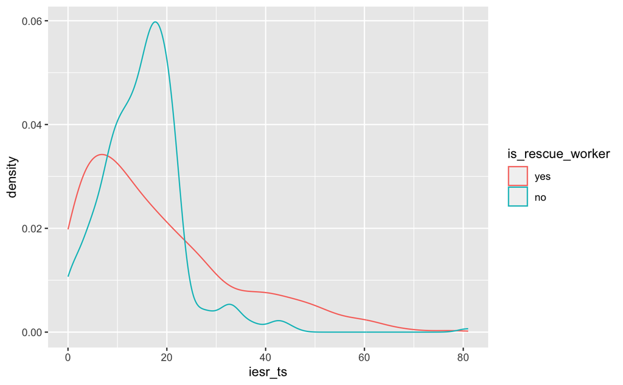

```r
ggplot(all_items, aes(x = iesr_ts, colour = is_rescue_worker)) +
  geom_density()
```

```r
all_items |>
  group_by(is_rescue_worker) |>
  summarize(
    avg_iesr = mean(iesr_ts)
  )
```

| is_rescue_worker | avg_iesr |
| --- | --- |
| yes | 18.32842 |
| no | 15.17702 |

```r
m10 <- brm(
  iesr_ts ~ is_rescue_worker,
  family = brmsfamily("hurdle_gamma"),
  backend = "cmdstanr",
  all_items
)
```

```
Using 10 posterior draws for ppc type 'dens_overlay' by default.
```

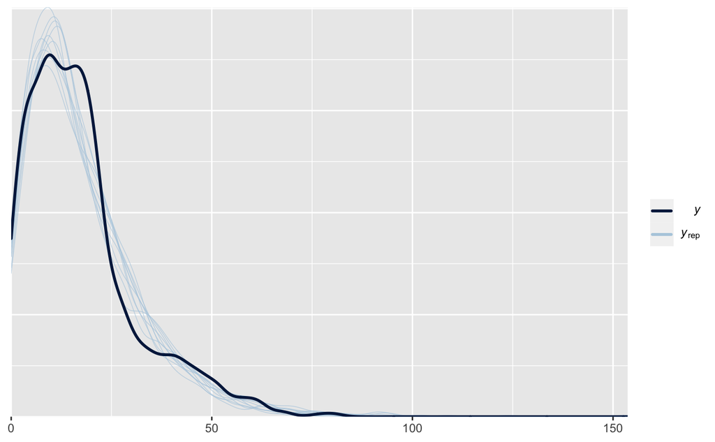

```r
pp_check(m10)
```

```r
summary(m10)
```

```
 Family: hurdle_gamma
  Links: mu = log; shape = identity; hu = identity
Formula: iesr_ts ~ is_rescue_worker
   Data: all_items (Number of observations: 1068)
  Draws: 4 chains, each with iter = 2000; warmup = 1000; thin = 1;
         total post-warmup draws = 4000

Population-Level Effects:
                   Estimate Est.Error l-95% CI u-95% CI Rhat Bulk_ESS Tail_ESS
Intercept              2.95      0.03     2.90     3.01 1.00     4768     2788
is_rescue_workerno    -0.20      0.05    -0.31    -0.10 1.00     4530     2940

Family Specific Parameters:
      Estimate Est.Error l-95% CI u-95% CI Rhat Bulk_ESS Tail_ESS
shape     1.78      0.07     1.65     1.92 1.00     5180     3519
hu        0.04      0.01     0.03     0.05 1.00     4486     3185

Draws were sampled using sample(hmc). For each parameter, Bulk_ESS
and Tail_ESS are effective sample size measures, and Rhat is the potential
scale reduction factor on split chains (at convergence, Rhat = 1).
```

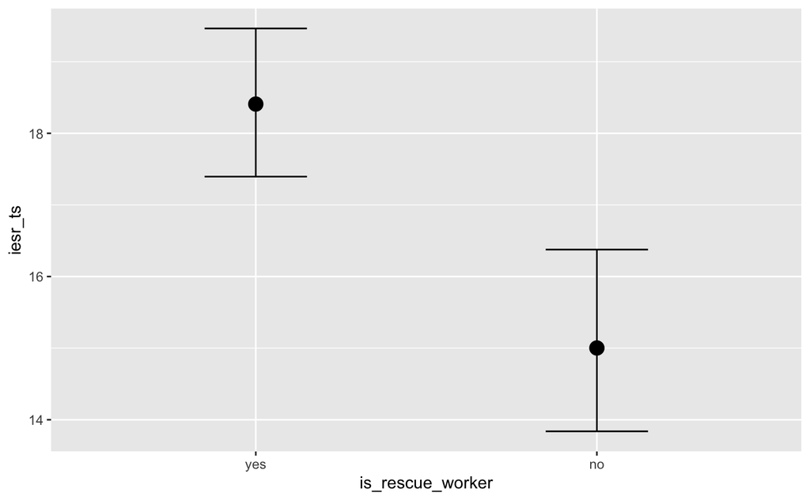

```r
me <- conditional_effects(
  m10, "is_rescue_worker"
)
plot(me, points = FALSE)
```

The factor model does not fit very well, but the Omega for each subscale is acceptable.

```r
iesr_df <- all_items |>
  dplyr::select(starts_with("ies_"))
```

```r
model <- '
    intrusion =~ ies_5 + ies_4 + ies_7 + ies_6 + ies_3 + ies_1
    avoidance =~ ies_18 + ies_17 + ies_22 + ies_21 + ies_16 + ies_19 + ies_15
    hyperarousal =~ ies_12 + ies_11 + ies_9 + ies_10 + ies_13

    intrusion ~~ intrusion
    avoidance ~~ avoidance
    hyperarousal ~~ hyperarousal
'
```

```r
fit <- cfa(model, data = iesr_df, std.lv = TRUE)
summary(fit, standardize = TRUE)
```

```
lavaan 0.6.15 ended normally after 25 iterations

  Estimator                                         ML
  Optimization method                           NLMINB
  Number of model parameters                        39

  Number of observations                          1068

Model Test User Model:

  Test statistic                              1598.143
  Degrees of freedom                               132
  P-value (Chi-square)                           0.000

Parameter Estimates:

  Standard errors                             Standard
  Information                                 Expected
  Information saturated (h1) model          Structured

Latent Variables:
                   Estimate  Std.Err  z-value  P(>|z|)   Std.lv  Std.all
  intrusion =~
    ies_5             0.292    0.040    7.358    0.000    0.292    0.236
    ies_4             0.569    0.029   19.480    0.000    0.569    0.575
    ies_7             0.280    0.026   10.947    0.000    0.280    0.344
    ies_6             0.834    0.030   27.478    0.000    0.834    0.750
    ies_3             0.896    0.028   32.331    0.000    0.896    0.839
    ies_1             0.843    0.030   28.090    0.000    0.843    0.762
  avoidance =~
    ies_18            0.633    0.023   27.447    0.000    0.633    0.743
    ies_17            0.598    0.030   19.799    0.000    0.598    0.577
    ies_22            0.445    0.029   15.292    0.000    0.445    0.462
    ies_21            0.471    0.029   16.055    0.000    0.471    0.482
    ies_16            0.807    0.028   28.365    0.000    0.807    0.760
    ies_19            0.498    0.021   23.203    0.000    0.498    0.655
    ies_15            0.671    0.026   26.038    0.000    0.671    0.715
  hyperarousal =~
    ies_12            0.673    0.026   25.566    0.000    0.673    0.704
    ies_11            0.673    0.035   19.087    0.000    0.673    0.558
```

[output cut: 20 more lines]

```
   .ies_6             0.541    0.028   19.164    0.000    0.541    0.437
   .ies_3             0.337    0.021   15.708    0.000    0.337    0.295
   .ies_1             0.513    0.027   18.855    0.000    0.513    0.419
   .ies_18            0.326    0.016   20.143    0.000    0.326    0.448
   .ies_17            0.718    0.033   21.941    0.000    0.718    0.667
   .ies_22            0.728    0.032   22.478    0.000    0.728    0.786
   .ies_21            0.730    0.033   22.404    0.000    0.730    0.767
   .ies_16            0.475    0.024   19.786    0.000    0.475    0.422
   .ies_19            0.329    0.015   21.332    0.000    0.329    0.571
   .ies_15            0.431    0.021   20.610    0.000    0.431    0.489
   .ies_12            0.462    0.022   20.931    0.000    0.462    0.505
   .ies_11            1.003    0.045   22.153    0.000    1.003    0.689
   .ies_9             0.522    0.027   19.664    0.000    0.522    0.403
   .ies_10            0.409    0.019   21.107    0.000    0.409    0.524
   .ies_13            0.341    0.016   20.962    0.000    0.341    0.508
```

```r
fitMeasures(fit)
```

```
                 npar                  fmin                 chisq                    df                pvalue
               39.000                 0.748              1598.143               132.000                 0.000
       baseline.chisq           baseline.df       baseline.pvalue                   cfi                   tli
             9136.105               153.000                 0.000                 0.837                 0.811
                 nnfi                   rfi                   nfi                  pnfi                   ifi
                0.811                 0.797                 0.825                 0.712                 0.837
                  rni                  logl     unrestricted.logl                   aic                   bic
                0.837            -23244.664            -22445.593             46567.328             46761.296
               ntotal                  bic2                 rmsea        rmsea.ci.lower        rmsea.ci.upper
             1068.000             46637.425                 0.102                 0.098                 0.106
       rmsea.ci.level          rmsea.pvalue        rmsea.close.h0 rmsea.notclose.pvalue     rmsea.notclose.h0
                0.900                 0.000                 0.050                 1.000                 0.080
                  rmr            rmr_nomean                  srmr          srmr_bentler   srmr_bentler_nomean
                0.072                 0.072                 0.070                 0.070                 0.070
                 crmr           crmr_nomean            srmr_mplus     srmr_mplus_nomean                 cn_05
                0.074                 0.074                 0.070                 0.070               107.800
                cn_01                   gfi                  agfi                  pgfi                   mfi
              116.418                 0.827                 0.776                 0.639                 0.503
                 ecvi
                1.569
```

```r
semTools::reliability(fit)
```

```
       intrusion avoidance hyperarousal
alpha  0.7419496 0.8162512    0.8053576
omega  0.7718313 0.8196984    0.8092814
omega2 0.7718313 0.8196984    0.8092814
omega3 0.7772066 0.8147180    0.8076260
avevar 0.3980811 0.4033546    0.4649398
```

```r
compRelSEM(fit)
```

```
   intrusion    avoidance hyperarousal
       0.777        0.815        0.808
```

[output not shown]

```
Omega
Call: omegah(m = m, nfactors = nfactors, fm = fm, key = key, flip = flip,
    digits = digits, title = title, sl = sl, labels = labels,
    plot = plot, n.obs = n.obs, rotate = rotate, Phi = Phi, option = option,
    covar = covar)
Alpha:                 0.94
G.6:                   0.95
Omega Hierarchical:    0.74
Omega H asymptotic:    0.78
Omega Total            0.95

Schmid Leiman Factor loadings greater than  0.2
```

|  | g | F1* | F2* | F3* | h2 | u2 | p2 |
| --- | --- | --- | --- | --- | --- | --- | --- |
| ies_1 | 0.66 |  | 0.37 |  | 0.57 | 0.43 | 0.75 |
| ies_2 | 0.65 | 0.32 | 0.21 |  | 0.60 | 0.40 | 0.71 |
| ies_3 | 0.72 |  | 0.37 |  | 0.66 | 0.34 | 0.78 |
| ies_4 | 0.52 | 0.36 |  |  | 0.41 | 0.59 | 0.67 |
| ies_5 | 0.21 |  |  | 0.29 | 0.17 | 0.83 | 0.26 |
| ies_6 | 0.69 |  | 0.42 |  | 0.66 | 0.34 | 0.72 |
| ies_7 | 0.33 | 0.25 |  |  | 0.20 | 0.80 | 0.55 |
| ies_8 | 0.46 | 0.36 |  | 0.26 | 0.41 | 0.59 | 0.51 |
| ies_9 | 0.73 |  | 0.31 |  | 0.66 | 0.34 | 0.82 |
| ies_10 | 0.56 | 0.47 |  |  | 0.53 | 0.47 | 0.59 |

[output cut: 13 more lines]

```
With Sums of squares  of:
   g  F1*  F2*  F3*
7.79 2.23 0.83 0.95

general/max  3.49   max/min =   2.68
mean percent general =  0.63    with sd =  0.14 and cv of  0.22
Explained Common Variance of the general factor =  0.66

The degrees of freedom are 187  and the fit is  19.57
The number of observations was  1068  with Chi Square =  20679.43  with prob <  0
The root mean square of the residuals is  0.04
The df corrected root mean square of the residuals is  0.04
RMSEA index =  0.32  and the 10 % confidence intervals are  0.317 0.324
BIC =  19375.38

Compare this with the adequacy of just a general factor and no group factors
The degrees of freedom for just the general factor are 230  and the fit is  23.7
The number of observations was  1068  with Chi Square =  25065.48  with prob <  0
The root mean square of the residuals is  0.12
The df corrected root mean square of the residuals is  0.12

RMSEA index =  0.318  and the 10 % confidence intervals are  0.315 0.321
BIC =  23461.56

Measures of factor score adequacy
                                                        g        F1*      F2*         F3*
Correlation of scores with factors                3619.69    1218.07   156.45     5362.89
Multiple R square of scores with factors      13102186.66 1483696.43 24476.06 28760615.87
Minimum correlation of factor score estimates 26204372.31 2967391.87 48951.11 57521230.73

 Total, General and Subset omega for each subset
                                                 g  F1*  F2*  F3*
Omega total for total scores and subscales    0.95 0.92 0.88 0.64
Omega general for total scores and subscales  0.74 0.63 0.71 0.32
Omega group for total scores and subscales    0.14 0.28 0.18 0.32
```

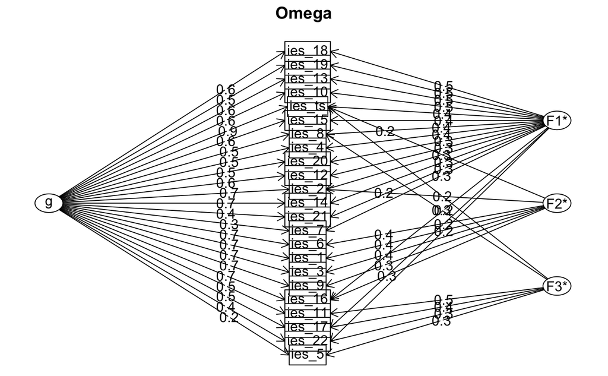

```r
psych::omega(iesr_df)
```

https://rpubs.com/asghar_minaei/857065

```r
compRelSEM(fit, return.total = TRUE)
```

```
   intrusion    avoidance hyperarousal        total
       0.777        0.815        0.808        0.902
```

## COPE scale

```r
all_items$pos_reinterpretation <- with(all_items, cope_1 + cope_29 + cope_38 + cope_59)
all_items$mental_disengagement <- with(all_items, cope_2 + cope_16 + cope_31 + cope_43)
all_items$venting <- with(all_items, cope_3 + cope_17 + cope_28 + cope_46)
all_items$seeking_instrumental_support <- with(all_items, cope_4 + cope_14 + cope_30 + cope_45)
all_items$active_coping <- with(all_items, cope_5 + cope_25 + cope_47 + cope_58)
all_items$denial <- with(all_items, cope_6 + cope_27 + cope_40 + cope_57)
all_items$religion <- with(all_items, cope_7 + cope_18 + cope_48 + cope_60)
all_items$humor <- with(all_items, cope_8 + cope_20 + cope_36 + cope_50)
all_items$behavioral_disengagement <- with(all_items, cope_9 + cope_24 + cope_37 + cope_51)
all_items$restraint <- with(all_items, cope_10 + cope_22 + cope_41 + cope_49)
all_items$seeking_emotional_support <- with(all_items, cope_11 + cope_23 + cope_34 + cope_52)
all_items$substance_use <- with(all_items, cope_12 + cope_26 + cope_35 + cope_53)
all_items$acceptance <- with(all_items, cope_13 + cope_21 + cope_44 + cope_54)
all_items$suppr_competing_activities <- with(all_items, cope_15 + cope_33 + cope_42 + cope_55)
all_items$planning <- with(all_items, cope_19 + cope_32 + cope_39 + cope_56)
```

```r
cope_scales <- c(
  "pos_reinterpretation", "active_coping", "restraint", "acceptance",
                  "suppr_competing_activities", "planning", "venting",
  "seeking_instrumental_support", "religion",
                   "seeking_emotional_support", "mental_disengagement", "denial", "humor",
                     "behavioral_disengagement", "substance_use"
)

cope_df <- subset(all_items, select=cope_scales)


fit0 <- factanal(cope_df, 3, rotation="promax")
print(fit0, digits=2, cutoff=0.3, sort=TRUE)
```

```
Call:
factanal(x = cope_df, factors = 3, rotation = "promax")

Uniquenesses:
        pos_reinterpretation                active_coping                    restraint                   acceptance
                        0.61                         0.51                         0.77                         0.87
  suppr_competing_activities                     planning                      venting seeking_instrumental_support
                        0.52                         0.36                         0.69                         0.52
                    religion    seeking_emotional_support         mental_disengagement                       denial
                        0.89                         0.03                         0.56                         0.48
                       humor     behavioral_disengagement                substance_use
                        0.70                         0.54                         0.53

Loadings:
                             Factor1 Factor2 Factor3
pos_reinterpretation          0.62
active_coping                 0.70
suppr_competing_activities    0.71
planning                      0.79
mental_disengagement                  0.63
denial                                0.72
humor                                 0.54
behavioral_disengagement              0.64
substance_use                         0.67
seeking_instrumental_support                  0.58
seeking_emotional_support                     0.99
restraint                     0.47
acceptance                    0.35
venting                               0.31    0.46
religion                              0.34

               Factor1 Factor2 Factor3
SS loadings       2.43    2.39    1.60
Proportion Var    0.16    0.16    0.11
Cumulative Var    0.16    0.32    0.43

Factor Correlations:
        Factor1 Factor2 Factor3
Factor1   1.000  -0.210  -0.032
Factor2  -0.210   1.000  -0.071
Factor3  -0.032  -0.071   1.000

Test of the hypothesis that 3 factors are sufficient.
The chi square statistic is 583.09 on 63 degrees of freedom.
The p-value is 2.73e-85
```

```r
model <- '
    active_cop =~ NA*pos_reinterpretation + active_coping +
                  suppr_competing_activities + planning +
                  restraint + seeking_instrumental_support #+ acceptance
    soc_emo_cop =~ NA*seeking_instrumental_support +
                    seeking_emotional_support + venting
    avoidance_cop =~ NA*mental_disengagement + denial + humor +
                     behavioral_disengagement + substance_use
                     # religion

    active_cop ~~ 1*active_cop
    soc_emo_cop ~~ 1*soc_emo_cop
    avoidance_cop ~~ 1*avoidance_cop

    behavioral_disengagement    ~~  venting
    behavioral_disengagement    ~~  substance_use

'
```

```r
fit1 <- sem(model, data = all_items)
summary(fit1, standardized = TRUE)
```

[output not shown]

[output cut: 25 more lines]

```
    soc_emo_cop       1.000                               1.000    1.000
    avoidance_cop     1.000                               1.000    1.000
   .pos_rentrprttn    2.891    0.109   26.445    0.000    2.891    0.606
   .active_coping   -29.158    1.470  -19.841    0.000  -29.158   -0.263
   .sppr_cmptng_ct    3.655    0.139   26.299    0.000    3.655    0.639
   .planning          3.755    0.142   26.485    0.000    3.755    0.595
   .restraint         3.404    0.131   26.001    0.000    3.404    0.692
   .skng_nstrmntl_    3.891    0.192   20.313    0.000    3.891    0.533
   .skng_mtnl_sppr   -1.762    1.011   -1.742    0.081   -1.762   -0.168
   .venting           6.626    0.317   20.922    0.000    6.626    0.800
   .mentl_dsnggmnt    4.198    0.235   17.863    0.000    4.198    0.562
   .denial            2.714    0.260   10.433    0.000    2.714    0.330
   .humor             6.410    0.323   19.872    0.000    6.410    0.664
   .bhvrl_dsnggmnt    3.562    0.166   21.508    0.000    3.562    0.790
   .substance_use     5.525    0.278   19.895    0.000    5.525    0.673
```

```r
fitMeasures(fit1)
```

```
                 npar                  fmin                 chisq                    df                pvalue
               32.000                 0.244               520.550                59.000                 0.000
       baseline.chisq           baseline.df       baseline.pvalue                   cfi                   tli
             4286.931                78.000                 0.000                 0.890                 0.855
                 nnfi                   rfi                   nfi                  pnfi                   ifi
                0.855                 0.839                 0.879                 0.665                 0.891
                  rni                  logl     unrestricted.logl                   aic                   bic
                0.890            -30973.213            -30712.938             62010.426             62169.579
               ntotal                  bic2                 rmsea        rmsea.ci.lower        rmsea.ci.upper
             1068.000             62067.941                 0.086                 0.079                 0.092
       rmsea.ci.level          rmsea.pvalue        rmsea.close.h0 rmsea.notclose.pvalue     rmsea.notclose.h0
                0.900                 0.000                 0.050                 0.916                 0.080
                  rmr            rmr_nomean                  srmr          srmr_bentler   srmr_bentler_nomean
                0.548                 0.548                 0.078                 0.078                 0.078
                 crmr           crmr_nomean            srmr_mplus     srmr_mplus_nomean                 cn_05
                0.084                 0.084                 0.078                 0.078               160.888
                cn_01                   gfi                  agfi                  pgfi                   mfi
              179.836                 0.934                 0.898                 0.605                 0.806
                 ecvi
                0.547
```

```r
modindices(fit1, minimum.value = 10, sort = TRUE)
```

|  | lhs | op | rhs | mi | epc | sepc.lv | sepc.all | sepc.nox |
| --- | --- | --- | --- | --- | --- | --- | --- | --- |
| 58 | avoidance_cop | =~ | seeking_instrumental_support | 47.731 | -0.504 | -0.504 | -0.187 | -0.187 |
| 118 | seeking_emotional_support | ~~ | venting | 47.728 | -16.466 | -16.466 | -5.310 | -5.310 |
| 60 | avoidance_cop | =~ | venting | 46.491 | 0.597 | 0.597 | 0.207 | 0.207 |
| 127 | venting | ~~ | substance_use | 37.227 | 1.162 | 1.162 | 0.194 | 0.194 |
| 48 | soc_emo_cop | =~ | mental_disengagement | 31.797 | 0.370 | 0.370 | 0.135 | 0.135 |
| 57 | avoidance_cop | =~ | restraint | 31.726 | 0.405 | 0.405 | 0.183 | 0.183 |
| 41 | active_cop | =~ | behavioral_disengagement | 30.299 | -0.329 | -0.329 | -0.155 | -0.155 |
| 62 | pos_reinterpretation | ~~ | suppr_competing_activities | 26.219 | -0.605 | -0.605 | -0.201 | -0.201 |
| 124 | venting | ~~ | mental_disengagement | 26.162 | 0.849 | 0.849 | 0.162 | 0.162 |
| 85 | suppr_competing_activities | ~~ | restraint | 22.961 | 0.595 | 0.595 | 0.170 | 0.170 |

[output cut: 16 more lines]

```r
semTools::reliability(fit1, return.total = TRUE)
```

```
       active_cop soc_emo_cop avoidance_cop     total
alpha   0.7603622   0.6952840     0.7747534 0.6564449
omega   0.7821148   0.8006931     0.7473066 0.7756819
omega2  0.7427025   0.7712483     0.7473066 0.7756819
omega3  0.7404904   0.7930596     0.7307279 0.7776544
avevar         NA          NA     0.4116625 0.4866313
```

Create COPE sub-scales scores using *all* items – note that SEM analyses suggest to drop some of the items.

```r
all_items$active_coping <- with(
  all_items, pos_reinterpretation + active_coping +
  suppr_competing_activities + planning + restraint +
    seeking_instrumental_support + acceptance
)

all_items$avoidance_coping <- with(
  all_items, mental_disengagement + denial + humor +
  behavioral_disengagement + substance_use + religion
)

all_items$soc_emo_coping <- with(
  all_items, seeking_instrumental_support +
  seeking_emotional_support + venting
)
```

```r
t.test(active_coping ~ is_rescue_worker, data= all_items)
```

```
    Welch Two Sample t-test

data:  active_coping by is_rescue_worker
t = 4.9637, df = 584.72, p-value = 9.085e-07
alternative hypothesis: true difference in means between group yes and group no is not equal to 0
95 percent confidence interval:
 2.122154 4.901093
sample estimates:
mean in group yes  mean in group no
         79.38740          75.87578
```

```r
t.test(avoidance_coping ~ is_rescue_worker, data= all_items)
```

```
    Welch Two Sample t-test

data:  avoidance_coping by is_rescue_worker
t = -17.686, df = 404.96, p-value < 2.2e-16
alternative hypothesis: true difference in means between group yes and group no is not equal to 0
95 percent confidence interval:
 -15.46809 -12.37342
sample estimates:
mean in group yes  mean in group no
         35.03887          48.95963
```

```r
t.test(soc_emo_coping ~ is_rescue_worker, data = all_items)
```

```
    Welch Two Sample t-test

data:  soc_emo_coping by is_rescue_worker
t = -3.6061, df = 672.87, p-value = 0.0003338
alternative hypothesis: true difference in means between group yes and group no is not equal to 0
95 percent confidence interval:
 -2.4561404 -0.7243834
sample estimates:
mean in group yes  mean in group no
         29.97185          31.56211
```

```r
model2_cope <- '
    active_cop =~ NA*pos_reinterpretation + active_coping +
                  suppr_competing_activities + planning +
                  restraint # + seeking_instrumental_support + acceptance
    # soc_emo_cop =~ NA*seeking_instrumental_support +
    #                 seeking_emotional_support + venting
    avoidance_cop =~ NA*mental_disengagement + denial + humor +
                     behavioral_disengagement + substance_use
                     # religion

    active_cop ~~ 1*active_cop
    # soc_emo_cop ~~ 1*soc_emo_cop
    avoidance_cop ~~ 1*avoidance_cop

    # behavioral_disengagement  ~~  venting
    behavioral_disengagement    ~~  substance_use

'
```

```r
summary(fit2, standardized = TRUE)
```

[output not shown]

```r
modificationIndices(fit2, sort = TRUE)
```

|  | lhs | op | rhs | mi | epc | sepc.lv | sepc.all | sepc.nox |
| --- | --- | --- | --- | --- | --- | --- | --- | --- |
| 28 | active_cop | =~ | behavioral_disengagement | 31.000 | -0.345 | -0.345 | -0.158 | -0.158 |
| 34 | avoidance_cop | =~ | restraint | 29.260 | 0.389 | 0.389 | 0.175 | 0.175 |
| 53 | suppr_competing_activities | ~~ | restraint | 23.603 | 0.608 | 0.608 | 0.174 | 0.174 |
| 36 | pos_reinterpretation | ~~ | suppr_competing_activities | 22.817 | -0.576 | -0.576 | -0.189 | -0.189 |
| 63 | planning | ~~ | behavioral_disengagement | 18.879 | -0.431 | -0.431 | -0.161 | -0.161 |
| 49 | active_coping | ~~ | humor | 17.175 | 0.543 | 0.543 | 0.146 | 0.146 |
| 41 | pos_reinterpretation | ~~ | humor | 16.833 | 0.620 | 0.620 | 0.139 | 0.139 |
| 55 | suppr_competing_activities | ~~ | denial | 15.171 | 0.488 | 0.488 | 0.167 | 0.167 |
| 27 | active_cop | =~ | humor | 14.826 | 0.357 | 0.357 | 0.115 | 0.115 |
| 46 | active_coping | ~~ | restraint | 14.250 | -0.401 | -0.401 | -0.136 | -0.136 |

[output cut: 44 more lines]

```r
fitMeasures(fit2)
```

```
                 npar                  fmin                 chisq                    df                pvalue
               22.000                 0.104               221.851                33.000                 0.000
       baseline.chisq           baseline.df       baseline.pvalue                   cfi                   tli
             3038.324                45.000                 0.000                 0.937                 0.914
                 nnfi                   rfi                   nfi                  pnfi                   ifi
                0.914                 0.900                 0.927                 0.680                 0.937
                  rni                  logl     unrestricted.logl                   aic                   bic
                0.937            -23475.543            -23364.618             46995.086             47104.504
               ntotal                  bic2                 rmsea        rmsea.ci.lower        rmsea.ci.upper
             1068.000             47034.628                 0.073                 0.064                 0.082
       rmsea.ci.level          rmsea.pvalue        rmsea.close.h0 rmsea.notclose.pvalue     rmsea.notclose.h0
                0.900                 0.000                 0.050                 0.116                 0.080
                  rmr            rmr_nomean                  srmr          srmr_bentler   srmr_bentler_nomean
                0.365                 0.365                 0.062                 0.062                 0.062
                 crmr           crmr_nomean            srmr_mplus     srmr_mplus_nomean                 cn_05
                0.069                 0.069                 0.062                 0.062               229.185
                cn_01                   gfi                  agfi                  pgfi                   mfi
              264.692                 0.960                 0.934                 0.576                 0.915
                 ecvi
                0.249
```

## Self-compassion scale

```r
fm <- lm(avoidance_coping ~ ts_sc * is_rescue_worker, all_items)
summary(fm)
```

```
Call:
lm(formula = avoidance_coping ~ ts_sc * is_rescue_worker, data = all_items)

Residuals:
    Min      1Q  Median      3Q     Max
-28.191  -5.712  -0.653   5.119  33.433

Coefficients:
                         Estimate Std. Error t value Pr(>|t|)
(Intercept)              21.31349    1.92466  11.074  < 2e-16 ***
ts_sc                     0.18601    0.02570   7.239 8.64e-13 ***
is_rescue_workerno        1.51067    4.07256   0.371  0.71076
ts_sc:is_rescue_workerno  0.13704    0.05089   2.693  0.00719 **
---
Signif. codes:  0 ‘***’ 0.001 ‘**’ 0.01 ‘*’ 0.05 ‘.’ 0.1 ‘ ’ 1

Residual standard error: 9.039 on 1064 degrees of freedom
Multiple R-squared:  0.3756,    Adjusted R-squared:  0.3738
F-statistic: 213.3 on 3 and 1064 DF,  p-value: < 2.2e-16
```

```r
plot(density(all_items$avoidance_coping))
```

[output not shown]

```r
library("brms")
```

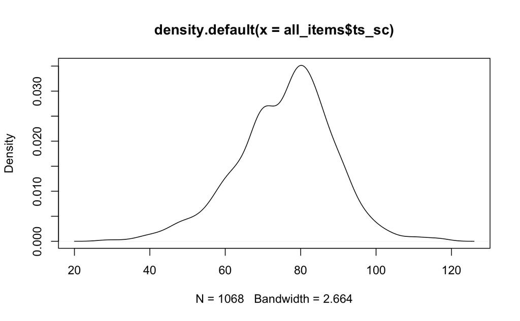

```r
plot(density(all_items$ts_sc))
```

```r
fit_1 <- brm(
  ts_sc ~ is_rescue_worker,
  family = student(),
  backend = "cmdstanr",
  data = all_items
)
```

```
Using 10 posterior draws for ppc type 'dens_overlay' by default.
```

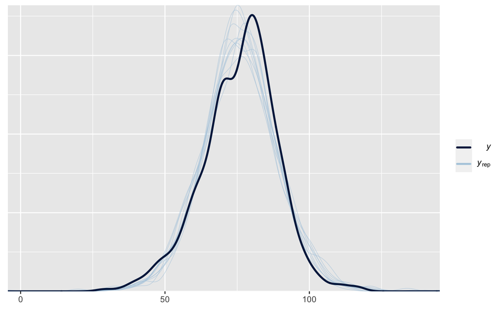

```r
pp_check(fit_1)
```

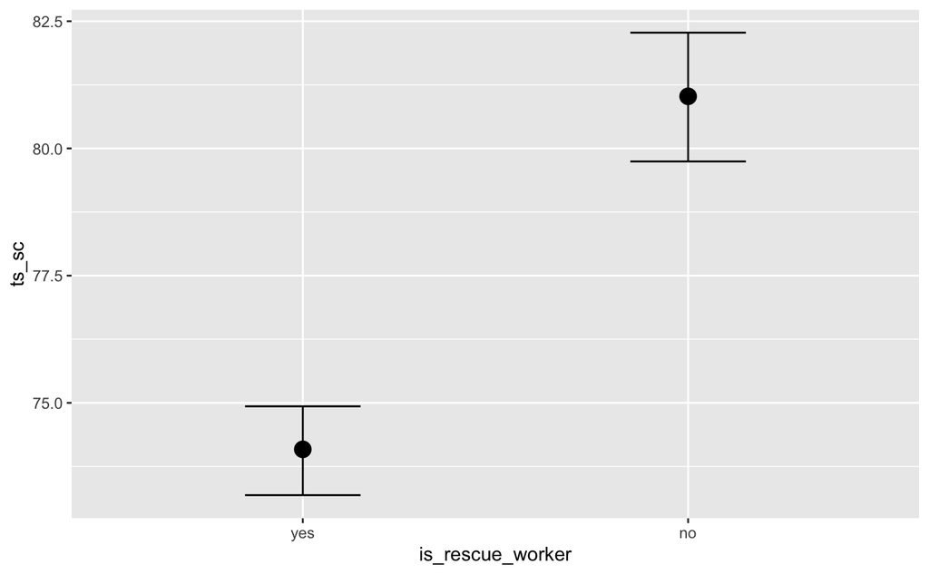

```r
me <- conditional_effects(
  fit_1, "is_rescue_worker"
)
plot(me, points = FALSE)
```

```r
summary(fit_1)
```

```
 Family: student
  Links: mu = identity; sigma = identity; nu = identity
Formula: ts_sc ~ is_rescue_worker
   Data: all_items (Number of observations: 1068)
  Draws: 4 chains, each with iter = 2000; warmup = 1000; thin = 1;
         total post-warmup draws = 4000

Population-Level Effects:
                   Estimate Est.Error l-95% CI u-95% CI Rhat Bulk_ESS Tail_ESS
Intercept             74.07      0.45    73.19    74.93 1.00     3556     2618
is_rescue_workerno     6.94      0.80     5.41     8.53 1.00     3709     2912

Family Specific Parameters:
      Estimate Est.Error l-95% CI u-95% CI Rhat Bulk_ESS Tail_ESS
sigma    11.31      0.42    10.49    12.11 1.00     2512     2685
nu       12.50      5.27     6.55    25.64 1.00     2434     1949

Draws were sampled using sample(hmc). For each parameter, Bulk_ESS
and Tail_ESS are effective sample size measures, and Rhat is the potential
scale reduction factor on split chains (at convergence, Rhat = 1).
```

```r
fit_2 <- brm(
  active_coping ~ ts_sc * is_rescue_worker,
  family = asym_laplace(),
  backend = "cmdstanr",
  data = all_items
)
```

```
Using 10 posterior draws for ppc type 'dens_overlay' by default.
```

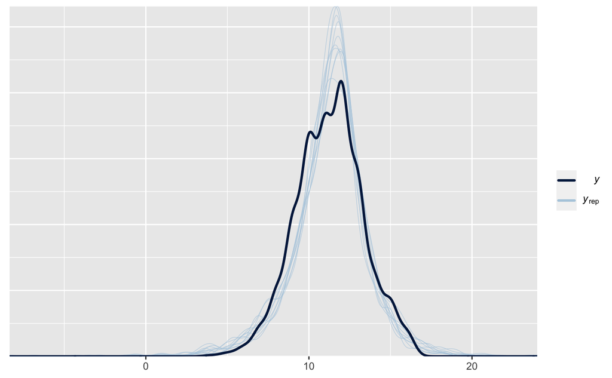

```r
pp_check(fit_2)
```

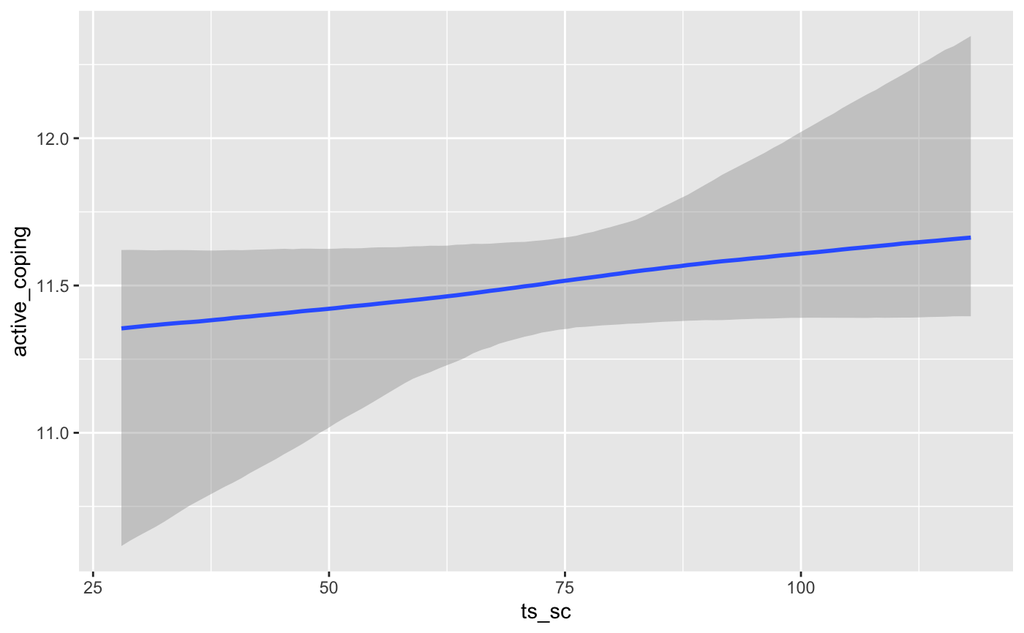

```r
me <- conditional_effects(
  fit_2, "ts_sc"
)
plot(me, points = FALSE)
```

```r
summary(fit_2)
```

[output not shown]

```r
all_items$active_coping <- all_items$pos_reinterpretation +
  all_items$active_coping + all_items$suppr_competing_activities +
  all_items$planning + all_items$restraint +
  all_items$seeking_instrumental_support

all_items$avoidance_coping <- all_items$mental_disengagement + all_items$denial +
  all_items$humor + all_items$behavioral_disengagement +
  all_items$substance_use
```